# Data Dictionary: *Shellfish* database

Are Strom

2022-11-04

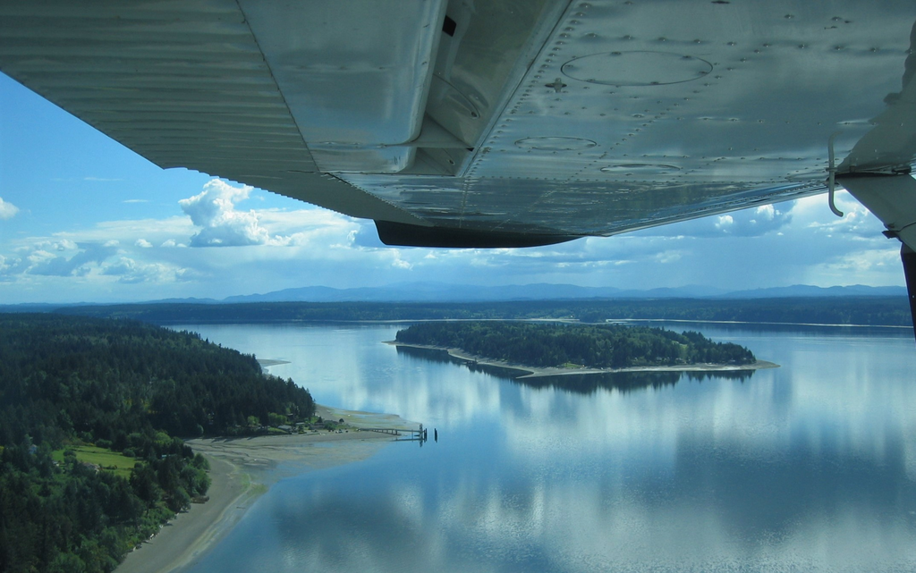

# Introduction

The Washington Department of Fish and Wildlife (WDFW) *Shellfish* database, described below, is currently used to house all data needed by the Puget Sound Intertidal Shellfish Unit to generate harvest estimates and season projections for clams and oysters in the Puget Sound Basin. It has also been designed to eventually enable the Crustacean management team to store data needed to manage shrimp and crab fisheries in Puget Sound.

#### Rationale for the *Shellfish* database

Development of the *Shellfish* database was motivated largely by:

- The need for WDFW biologists to aggregate a diverse set of data in one comprehensive and safe location.
- To desire to have harvest estimation scripts and programs pull all required data from a single source.
- The need to simplify sharing of data with outside entities.

The aim of the *Shellfish* data model is to provide a *one-database* solution for all survey and ancillary data needed to generate harvest estimates. Safety is enhanced by automated daily backups. The *shellfish* database enables biologist to keep all their survey, GIS, and management argreement data in one place. It avoids the need to piece together data from disparate sources during the analysis phase, and allows the current set of programming code used to generate harvest estimates to draw all needed datasets from one comprehensive, and properly linked location.

To facilitate data sharing, the *Shellfish* database has been designed using technology that make it easier to integrate and disseminate data. For example, by using universally unique IDs (UUIDs) for database keys, the need for central coordination in assigning database keys has been eliminated. By hosting the database remotely in the cloud, there is greater flexibility in engineering secure solutions to allow outside entities to easily access and use the data.

#### Database objective

The current objective of the *Shellfish* database is to store data related to recreational Puget Sound intertidal clam and oyster fisheries. The primary datasets include aerial counts of harvesters along selected Puget Sound beaches, creel survey data needed to generate CPUE estimates, boundaries of beaches and management areas, data on open and closed seasons for individual beaches, and annual negotiated harvest quotas. In the future the *Shellfish* database may also be leveraged to house data needed to assess harvest and trends of shrimp and crab stocks in Puget Sound.

Biologists apply a range of models to *Shellfish* data in order to calculate recreational harvest estimates. Outputs from these analyses are used to generate reports and project permissible harvest seasons for the coming year. The methods used to determine recreational clam and oyster harvest seasons in Puget Sound are outlined in a [WDFW Technical Report, 2007](https://wdfw.wa.gov/publications/00944).

#### Spatial features

The *Shellfish* database allows for storing spatial data types. With proper permissions, users can connect directly to the database server using GIS tools such as [QGIS](https://qgis.org/en/site/) to enter data, create, edit, or delete spatial features. When using [QGIS](https://qgis.org/en/site/), no additional server or middleware is required.

#### Overview diagram (table names only)

[figure not shown]

Table names only diagram

#### Notes on table descriptions

The sections below document table and field definitions for the *Shellfish* database. Table descriptions are arranged in descending hierarchical order starting with top-level header data for individual surveys, and ending with tables that store data for individual species encounters. Each section describes one or more *data* tables that share a common theme, or *level* in the hierarchy. Each section is preceeded by a diagram of table relationships.

Within each section, finer-grained descriptions of columns are provided for each table. For cases where columns link to a set of look-up table values, the relevant look-up tables are displayed directly below the *data* table descriptions. If a look-up table links to more than one *data* table, then the details of that table will only be displayed once…the first time it is mentioned.

The final four columns of each *data* table include:

- *created_datetime*: timestamptz(6)
- *created_by*: varchar(16)
- *modified_datetime*: timestamptz(6)
- *modified_by*: varchar(16)

These columns document the *time* (with timezone) that each record was created or modified, and the *individual* or *application* that created or modified the record. For brevity these columns will not be included in the *data* table descriptions below, but should be assumed to be present. The timezone is always converted from local and recorded in the database in UTC format (Coordinated Universal Time).

Look-up tables can be identified by the underscore *lut* suffix in the table name. For example, *data_source_lut*. The final two columns of each *look-up* table include:

- *obsolete_flag*: boolean
- *obsolete_datetime* timestamptz(6)

These columns document if a field has been *retired* or deemed *obsolete*, along with the date when the field was retired. For brevity these columns will not be included in the *look-up* table descriptions below, but should be assumed to be present.

Values recorded in each look-up table are displayed directly below the field definitions. For look-up tables with a large number of values, only a selection of values will be displayed. Some look-up tables such as the *species_lut* may be linked to more than one *data* table. In these cases the look-up table will only be displayed the first time it is mentioned.

#### Disclaimer

The *Shellfish* database is a work in progress and is subject to change. Please check with the *WDFW Puget Sound Intertidal Shellfish Unit* in Port Townsend, WA for the latest updates. This site will likely remain static and not reflect any changes implemented after December 2022.

# Location

### Location focused diagram

[figure not shown]

Location focused diagram

### Point Location

##### *Data associated with point locations*

| Column name | Data type | Nullable? | Key | Description |
| --- | --- | --- | --- | --- |
| point_location_id | uuid | No | Primary | Universally unique primary key |
| location_type_id | uuid | No | Foreign | Type of location (harvester count location, tide station, etc.) |
| beach_id | uuid | Yes | Foreign | Link to the beach table, describes characteristics of the beach |
| location_code | text | Yes |  | Short code to identify point |
| location_name | text | Yes |  | Name of point (place name, etc.) |
| location_description | text | Yes |  | Extended description of point |
| horizontal_accuracy | numeric (8, 2) | Yes |  | Estimated accuracy of the point in meters |
| comment_text | varchar (1000) | Yes |  | Additional comments regarding point location coordinates |
| gid | int4 | No |  | Unique integer ID required to manually edit geometry |
| geom | geometry | No |  | Coordinates stored in binary format. EPSG:2927 |

#### Location Type LUT

##### *Type of location (harvester count location, tide station, etc.)*

| Column name | Data type | Nullable? | Key | Description |
| --- | --- | --- | --- | --- |
| location_type_id | uuid | No | Primary | Universally unique primary key |
| location_type_description | varchar (50) | No |  | Description of location type |

| location_type_id | location_type_description |
| --- | --- |
| 1c4956f9-4d1e-457d-91e6-c59d2c5d93f5 | Tide reference station |
| cd9b431e-4750-4f54-a67e-a4252a4189f2 | Intertidal harvester count |

### Beach

##### *Tide corrections and descriptive information for specific beaches*

| Column name | Data type | Nullable? | Key | Description |
| --- | --- | --- | --- | --- |
| beach_id | uuid | No | Primary | Universally unique primary key |
| tide_station_location_id | uuid | No | Foreign | Link to the point_location table |
| local_beach_name | varchar (50) | Yes |  | Commonly used name for the beach. May differ from official name |
| beach_description | varchar (250) | Yes |  | Descriptive information for the beach |
| low_tide_correction_minutes | int4 | No |  | Low tide correction factor in minutes |
| low_tide_correction_feet | numeric (4, 2) | Yes |  | Low tide correction factor in feet |
| high_tide_correction_minutes | int4 | Yes |  | High tide correction factor in minutes |
| high_tide_correction_feet | numeric (4, 2) | Yes |  | High tide correction factor in feet |

### Beach Boundary History

##### *Effort estimation polygons, names, and assorted data for beaches*

| Column name | Data type | Nullable? | Key | Description |
| --- | --- | --- | --- | --- |
| beach_boundary_history_id | uuid | No | Primary | Universally unique primary key |
| beach_id | uuid | No | Foreign | Link to beach table |
| survey_type_id | uuid | No | Foreign | The type of survey conducted (Clam aerial, Clam ground, etc.) |
| beach_number | int4 | No |  | Beach Identification number (BIDN) |
| beach_name | text | No |  | Name of the beach |
| active_indicator | bool | No |  | Boolean indicating if boundary is currently active |
| active_datetime | timestamptz (6) | Yes |  | Date when boundary was activated |
| inactive_datetime | timestamptz (6) | Yes |  | Date when boundary was inactivated |
| inactive_reason | text | Yes |  | Reason boundary was inactivated |
| gid | int4 | No |  | Unique integer ID required to manually edit geometry |
| geom | geometry | Yes |  | Polygons of beaches stored in binary format, EPSG:2927 |

### Management Region LUT

##### *Polygons for shellfish management regions in Puget Sound*

| Column name | Data type | Nullable? | Key | Description |
| --- | --- | --- | --- | --- |
| management_region_id | uuid | No | Primary | Universally unique primary key |
| management_region_code | int4 | No |  | Numeric codes for the management regions |
| management_region_description | text | Yes |  | Descriptions of the management regions |
| gid | int4 | No |  | Unique integer ID required to manually edit geometry |
| geom | geometry | Yes |  | Polygons of management regions stored in binary format, EPSG:2927 |

### Shellfish Management Area LUT

##### *Polygons for shellfish management areas in Puget Sound*

| Column name | Data type | Nullable? | Key | Description |
| --- | --- | --- | --- | --- |
| shellfish_management_area_id | uuid | No | Primary | Universally unique primary key |
| shellfish_area_code | varchar (3) | No |  | Numeric codes for the management areas |
| shellfish_area_description | varchar (200) | Yes |  | Descriptions of the management areas |
| gid | int4 | No |  | Unique integer ID required to manually edit geometry |
| geom | geometry | Yes |  | Polygons of management areas stored in binary format, EPSG:2927 |

# Survey

### Survey level focused diagram

[figure not shown]

Survey level diagram

### Survey

##### *Top level header information for surveys*

| Column name | Data type | Nullable? | Key | Description |
| --- | --- | --- | --- | --- |
| survey_id | uuid | No | Primary | Universally unique primary key |
| survey_type_id | uuid | No | Foreign | The type of survey conducted (aerial, creel, etc.) |
| sampling_program_id | uuid | No | Foreign | The organizational unit that conducted the survey |
| beach_id | uuid | Yes | Foreign | Link to the beach table, describes characteristics of the beach |
| point_location_id | uuid | Yes | Foreign | Link to the point_location table, describes a specific point |
| area_surveyed_id | uuid | Yes | Foreign | Was entire beach surveyed (all, portion, etc.) |
| data_review_status_id | uuid | No | Foreign | Status of data review (final, preliminary, etc.) |
| survey_completion_status_id | uuid | No | Foreign | Was survey completed (partial, completed, etc.) |
| survey_datetime | timestamptz (6) | No |  | Date of the survey |
| start_datetime | timestamptz (6) | Yes |  | Time of day when survey started |
| end_datetime | timestamptz (6) | Yes |  | Time of day when survey ended |
| comment_text | varchar (1000) | Yes |  | Comments on survey |

#### Survey Type LUT

##### *The type of survey conducted (aerial, creel, etc.)*

| Column name | Data type | Nullable? | Key | Description |
| --- | --- | --- | --- | --- |
| survey_type_id | uuid | No | Primary | Universally unique primary key |
| survey_type_code | varchar (25) | No |  | Short code for survey type |
| survey_type_description | varchar (150) | No |  | Description of survey type |

| survey_type_id | survey_type_code | survey_type_description |
| --- | --- | --- |
| 7153c1cb-79cf-41d6-9fc1-966470c1460b | Clam aerial | Aerial harvester count, clam and oyster |
| 40b60612-2425-46b3-a5d5-c7fa9b4b0571 | Clam ground | Ground based, low tide harvester count, clam and oyster |
| df0305b3-c261-4cdf-a16a-660f15270be3 | Shrimp aerial | Aerial boat count, recreational shrimp harvest effort |
| ef32798a-d308-4bd6-9c13-7274342d93fc | Clam egress | Egress count, clam and oyster harvest |
| 7418ec2f-077a-45bf-9c6f-f10a368d406b | Clam creel | Creel survey, clam and oyster, catch per unit effort |
| 24cd3551-5739-4b44-a3f8-7637f708432d | Shrimp creel | Creel survey, shrimp, catch per unit effort |
| 7245cd5b-6462-41e4-b74c-7d6b5599a8eb | Oyster pop | Oyster population survey |
| 4bfd73c6-79dd-4428-a2b7-d8f1aa2326a4 | Clam pop | Clam population survey |

#### Sampling Program LUT

##### *The organizational unit that conducted the survey*

| Column name | Data type | Nullable? | Key | Description |
| --- | --- | --- | --- | --- |
| sampling_program_id | uuid | No | Primary | Universally unique primary key |
| agency_id | uuid | No | Foreign | Link to table listing external agencies. Not currently used |
| sampling_program_code | varchar (10) | No |  | Short code for unit |
| sampling_program_name | varchar (100) | No |  | Full name of organizational unit |

| sampling_program_id | agency_id | sampling_program_code | sampling_program_name |
| --- | --- | --- | --- |
| f1de1d54-d750-449f-a700-dc33ebec04c6 | bbe4126e-6081-44e3-af1b-012c98290603 | PSIS | Puget Sound intertidal shellfish program |

#### Area Surveyed LUT

##### *Description of the extent of a site that was surveyed*

| Column name | Data type | Nullable? | Key | Description |
| --- | --- | --- | --- | --- |
| area_surveyed_id | uuid | No | Primary | Universally unique primary key |
| area_surveyed_description | varchar (200) | No |  | Description of area categories (entire beach, most of beach, etc.) |

| area_surveyed_id | area_surveyed_description |
| --- | --- |
| 72e4eeea-ad0e-45d9-a2c9-3e2a5a5d06b7 | Entire beach |
| 7f0a8354-73e9-4f51-b4c8-7db253affd04 | Most of beach |
| d794e411-fb2d-4965-9ef0-2119c7cd0f07 | Portion of beach |
| 4e072477-e5f1-4a03-a14c-18e4aeade76e | Not applicable |

#### Data Review Status LUT

##### *Status of data review process*

| Column name | Data type | Nullable? | Key | Description |
| --- | --- | --- | --- | --- |
| data_review_status_id | uuid | No | Primary | Universally unique primary key |
| data_review_status_description | varchar (25) | No |  | Description of review categories (Preliminary, Final, etc.) |

| data_review_status_id | data_review_status_description |
| --- | --- |
| 48d228a2-6cdc-48e6-95e9-09b5e21d6489 | Preliminary |
| bdefcb1f-80c4-4921-9cf4-66c8dde02d4b | Final |
| acc0bee1-8404-4a52-b052-b176e5863cf8 | Unknown |
| cfc533e5-d5ef-44dc-ae1b-b5a3cfd59016 | Not applicable |
| 59cbf9d7-9015-49b6-874d-ea37ef663c56 | Reviewed |

#### Survey Completion Status LUT

##### *Was the survey completed?*

| Column name | Data type | Nullable? | Key | Description |
| --- | --- | --- | --- | --- |
| survey_completion_status_id | uuid | No | Primary | Universally unique primary key |
| completion_status_description | varchar (100) | No |  | Description of status categories |

| survey_completion_status_id | completion_status_description |
| --- | --- |
| 71ab2649-62d9-4d48-bad1-0b8a41f352a4 | Unknown |
| 9c72357a-8e98-4c98-888c-3412902bf0bf | Partial survey |
| 149d7253-6a25-4c4c-a7e2-a6cbbbb9850a | No survey conducted |
| d192b32e-0e4f-4719-9c9c-dec6593b1977 | Completed survey |

### Survey Sampler

##### *Associative table between survey and sampler tables*

| Column name | Data type | Nullable? | Key | Description |
| --- | --- | --- | --- | --- |
| survey_sampler_id | uuid | No | Primary | Universally unique primary key |
| survey_id | uuid | No | Foreign | Link to survey table |
| sampler_id | uuid | Yes | Foreign | Link to sampler table |

### Sampler

##### *Associative table between survey and sampler tables*

| Column name | Data type | Nullable? | Key | Description |
| --- | --- | --- | --- | --- |
| sampler_id | uuid | No | Primary | Universally unique primary key |
| first_name | varchar (50) | No |  | First name of sampler |
| last_name | varchar (50) | No |  | Last name of sampler |
| active_indicator | bool | No |  | Flag to indicate if sampler is still employed |

### Survey Mobile Device

##### *Associative table between survey table and mobile_device table*

| Column name | Data type | Nullable? | Key | Description |
| --- | --- | --- | --- | --- |
| survey_mobile_device_id | uuid | No | Primary | Universally unique primary key |
| survey_id | uuid | No | Foreign | Link to survey table |
| mobile_device_id | uuid | No | Foreign | Link to mobile_device table |

### Mobile Device

##### *Stores data for tracking mobile devices*

| Column name | Data type | Nullable? | Key | Description |
| --- | --- | --- | --- | --- |
| mobile_device_id | uuid | No | Primary | Universally unique primary key |
| mobile_device_type_id | uuid | No | Foreign | Type of device (Pad, GPS, etc.) |
| mobile_equipment_identifier | varchar (15) | No |  | Typically the MEID number printed on device |
| mobile_device_name | varchar (50) | No |  | Name of device |
| mobile_device_description | varchar (150) | No |  | Description of device |
| active_indicator | bool | No |  | Is the device still active and being used? |
| inactive_datetime | timestamptz (6) | Yes |  | Date the device was taken out of service |

#### Mobile Device Type LUT

##### *Type of mobile device*

| Column name | Data type | Nullable? | Key | Description |
| --- | --- | --- | --- | --- |
| mobile_device_type_id | uuid | No | Primary | Universally unique primary key |
| mobile_device_type_description | varchar (50) | No |  | Type of device (Pad, GPS, etc.) |

| mobile_device_type_id | mobile_device_type_description |
| --- | --- |

### Mobile Survey Form

##### *Table for tracking source of data collected with mobile device*

| Column name | Data type | Nullable? | Key | Description |
| --- | --- | --- | --- | --- |
| mobile_survey_form_id | uuid | No | Primary | Universally unique primary key |
| survey_id | uuid | No | Foreign | Link to survey table |
| parent_form_survey_id | int4 | No |  | Unique ID (integer) generated in parent form |
| parent_form_survey_guid | uuid | Yes | Foreign | GUID generated in parent form |
| parent_form_name | varchar (100) | Yes |  | Name of the parent form used to record data |
| parent_form_id | varchar (40) | Yes |  | Integer ID of the parent form used to record data |

# Survey Event

### Survey event focused diagram

[figure not shown]

Survey level diagram

### Survey Event

##### *Data for events occurring during a survey*

| Column name | Data type | Nullable? | Key | Description |
| --- | --- | --- | --- | --- |
| survey_event_id | uuid | No | Primary | Universally unique primary key |
| survey_id | uuid | No | Foreign | Link to survey table |
| event_location_id | uuid | Yes | Foreign | Link to point_location table |
| harvester_type_id | uuid | No | Foreign | Type of harvester counted (rec-clam, tribe-clam, etc.) |
| harvest_method_id | uuid | No | Foreign | Type of method used by harvester. Placeholder for non-bivalve fisheries |
| harvest_gear_type_id | uuid | No | Foreign | Type of gear used by harvester. Placeholder for non-bivalve fisheries |
| harvest_depth_range_id | uuid | No | Foreign | The approximate depth fished. Placeholder for non-bivalve fisheries |
| event_number | int4 | Yes |  | Sequence number for interview or encounter |
| event_datetime | timestamptz (6) | Yes |  | Time that interview or encounter occurred |
| harvester_count | int4 | Yes |  | Number of harvesters counted |
| harvest_gear_count | int4 | Yes |  | The number of units of gear counted. Placeholder for non-bivalve fisheries |
| harvester_zip_code | varchar (12) | Yes |  | The zip-code of the harvester. Intended for shrimp fisheries |
| comment_text | varchar (1000) | Yes |  | Additional comment on survey event |

#### Harvester Type LUT

##### *Categories of harvester type (rec-clam, tribe-clam, etc.)*

| Column name | Data type | Nullable? | Key | Description |
| --- | --- | --- | --- | --- |
| harvester_type_id | uuid | No | Primary | Universally unique primary key |
| harvester_type_code | varchar (25) | No |  | Code for harvester type |
| harvester_type_description | varchar (250) | No |  | Full description of harvester type |

| harvester_type_id | harvester_type_code | harvester_type_description |
| --- | --- | --- |
| df751c90-3f80-4a3c-b67c-c496dd2201b9 | na | Not applicable |
| 772f21fb-d07c-4998-a1d9-f7bb49df4db4 | rec-clam | Recreational clam or oyster harvester |
| e9582eaf-37a9-4b2e-823f-1c80f8ba7bd0 | rec-shrimp | Recreational shrimp harvester |
| 91dcb519-4b85-402b-9793-a5e98776c019 | rec-crab | Recreational crab harvester |
| 070980cf-74a7-4192-9319-f93325c7b6e4 | tribe-clam | Tribal clam or oyster harvester |

#### Harvest Method LUT

##### *Categories of harvest method. Intended for non-bivalve fisheries (crab, shrimp)*

| Column name | Data type | Nullable? | Key | Description |
| --- | --- | --- | --- | --- |
| harvest_method_id | uuid | No | Primary | Universally unique primary key |
| harvest_method_code | varchar (25) | No |  | Code for harvest method |
| harvest_method_description | varchar (250) | No |  | Full description of harvest method |

| harvest_method_id | harvest_method_code | harvest_method_description |
| --- | --- | --- |
| 68cb2cb1-77df-49f3-872b-5e3ba3299e14 | na | Not applicable |

#### Harvest Gear Type LUT

##### *Categories of harvest gear type. Intended for non-bivalve fisheries (crab, shrimp)*

| Column name | Data type | Nullable? | Key | Description |
| --- | --- | --- | --- | --- |
| harvest_gear_type_id | uuid | No | Primary | Universally unique primary key |
| harvest_gear_type_code | varchar (25) | No |  | Code for gear type |
| gear_type_description | varchar (250) | No |  | Full description of gear type |

| harvest_gear_type_id | harvest_gear_type_code | gear_type_description |
| --- | --- | --- |
| 5d1e6be6-cd85-498c-b2fa-43b370d951b4 | na | Not applicable |

#### Harvest Depth Range LUT

##### *Approximate depth fished. Intended for non-bivalve fisheries (crab, shrimp)*

| Column name | Data type | Nullable? | Key | Description |
| --- | --- | --- | --- | --- |
| harvest_depth_range_id | uuid | No | Primary | Universally unique primary key |
| harvest_depth_range | varchar (20) | No |  | Depth range |
| depth_range_description | varchar (50) | No |  | Description of depth range |

| harvest_depth_range_id | harvest_depth_range | depth_range_description |
| --- | --- | --- |
| b27281f7-9387-4a51-b91f-95748676f918 | na | Not applicable |

### Species Encounter

##### *Data for species encounters*

| Column name | Data type | Nullable? | Key | Description |
| --- | --- | --- | --- | --- |
| species_encounter_id | uuid | No | Primary | Universally unique primary key |
| survey_event_id | uuid | No | Foreign | Link to survey_event table |
| species_id | uuid | No | Foreign | Species that was encountered |
| species_location_id | uuid | Yes | Foreign | Link to point_location table |
| catch_result_type_id | uuid | No | Foreign | Was species kept or released |
| shell_condition_id | uuid | No | Foreign | Categories of shell condition (broken, intact, etc.) |
| species_count | int4 | No |  | Number of the species counted |
| species_weight_gram | numeric (8, 2) | Yes |  | Weight of the species in grams |
| no_head_indicator | bool | No |  | Intended for shrimp fisheries. Was the head removed? |
| comment_text | varchar (1000) | Yes |  | Additional comment on species encounter |

#### Species LUT

##### *List of shellfish species*

| Column name | Data type | Nullable? | Key | Description |
| --- | --- | --- | --- | --- |
| species_id | uuid | No | Primary | Universally unique primary key |
| taxo_name_id | int4 | Yes |  | Link to the WDFW Taxo_Name table |
| species_code | varchar (25) | No |  | Short code for species |
| common_name | varchar (100) | No |  | Common name of species |
| genus | varchar (50) | Yes |  | The genus name |
| species | varchar (50) | Yes |  | The species name |

| species_code | common_name | genus | species |
| --- | --- | --- | --- |
| manila | Manila clam | Venerupis | philippinarum |
| native | Native littleneck | Leukoma | staminea |
| butter | Butter clam | Saxidomus | gigantea |
| cockle | Cockle | Clinocardium | nuttallii |
| horse | Horse clam | Tresus | spp |
| eastern | Eastern soft-shell | Mya | arenaria |
| geoduck | Geoduck | Panopea | generosa |
| oyster | Pacific oyster | Crassostrea | gigas |
| varnish | Varnish clam | Nuttallia | obscurata |

#### Catch Result Type LUT

##### *End result of species encounter (kept, released, etc.)*

| Column name | Data type | Nullable? | Key | Description |
| --- | --- | --- | --- | --- |
| catch_result_type_id | uuid | No | Primary | Universally unique primary key |
| catch_result_type_code | varchar (20) | No |  | Short code for shell condition categories |
| catch_result_type_description | varchar (200) | No |  | Description of shell condition categories |

| catch_result_type_id | catch_result_type_code | catch_result_type_description |
| --- | --- | --- |
| 8891f1e8-f01b-401a-952b-76c9d589a83c | na | Not applicable |
| c8296015-491a-4427-826e-87cf57b485fd | kept | Animal was kept |
| fcaad9fc-4eec-4c79-b7c8-432c89bfecb3 | released | Animal was released |

#### Shell Condition LUT

##### *Condition of the shell (broken, unbroken, hardness category, etc.)*

| Column name | Data type | Nullable? | Key | Description |
| --- | --- | --- | --- | --- |
| shell_condition_id | uuid | No | Primary |  |
| shell_condition_code | varchar (20) | No |  |  |
| shell_condition_description | varchar (200) | No |  |  |

| shell_condition_id | shell_condition_code | shell_condition_description |
| --- | --- | --- |
| 040f8149-1003-45ae-8779-628033950378 | na | Not applicable |
| aea28523-5e72-4830-8b8a-12f064c3dab4 | unbroken clam | Clam not broken and scale functioning properly |
| f407a187-bfb1-496c-9b69-457df1dbd123 | broken clam | Clam either broken or scale malfunctioning |

# Harvest Estimation

### Harvest estimation diagram

[figure not shown]

Harvest estimation diagram

### Beach Season

##### *Data for open and closed harvest seasons on recreational beaches*

| Column name | Data type | Nullable? | Key | Description |
| --- | --- | --- | --- | --- |
| beach_season_id | uuid | No | Primary | Universally unique primary key |
| beach_id | uuid | No | Foreign | Link to beach table |
| season_status_id | uuid | No | Foreign | Status of the harvest season (open, closed, etc.) |
| species_group_id | uuid | No | Foreign | The group of species affected by the season regulation (clams, oysters, both) |
| season_start_datetime | timestamptz (6) | No |  | Start date of the season |
| season_end_datetime | timestamptz (6) | No |  | End date of the season |
| season_description | varchar (100) | Yes |  | Description of the season designation |
| comment_text | varchar (200) | Yes |  | Additional comments on the season designation |

#### Season Status LUT

##### *Status of the season designation (open, closed, etc)*

| Column name | Data type | Nullable? | Key | Description |
| --- | --- | --- | --- | --- |
| season_status_id | uuid | No | Primary | Universally unique primary key |
| season_status_code | varchar (2) | No |  | Code for the season status categories |
| season_status_description | varchar (200) | No |  | Description of the season status categories |

| season_status_id | season_status_code | season_status_description |
| --- | --- | --- |
| 81e9cbb4-4bbd-46fd-aab8-bc824d523d22 | OR | Season open by WDFW regulation |
| 61e84153-946f-4e12-ade0-def83b57c0d9 | CR | Season closed by WDFW regulation |
| 9b44fcf1-0d9d-4a14-a9cf-a8a526c0589e | OB | Season open by WA Dept of Health biotoxin bulletin |
| d012f782-1e89-497b-9f35-d3db28a6d75a | CB | Season closed by WA Dept of Health biotoxin bulletin |

#### Species Group LUT

##### *The group of species affected by the season regulation (clams, oysters, both)*

| Column name | Data type | Nullable? | Key | Description |
| --- | --- | --- | --- | --- |
| species_group_id | uuid | No | Primary | Universally unique primary key |
| species_group_code | varchar (10) | No |  | Code for the species group categories |
| species_group_description | varchar (50) | No |  | Description of the species group categories |

| species_group_id | species_group_code | species_group_description |
| --- | --- | --- |
| 65fcd0ba-d701-4ee1-9e1e-960bad82ece2 | Clam | All species of hardshell clams |
| 379db4d3-ec40-4ebf-b588-6f87d68ec303 | Oyster | All species of oysters |
| 433a6742-83e0-41d9-91c2-5818248a16d0 | Butter | Butter clams only |
| 1ebc008e-10e7-4c9c-b2a6-3b69651d9710 | Both | Both clams and oysters |
| 257a414f-5e0f-42c3-bc2e-d6ca25aae5f2 | Manila | Manila clams only |
| f9341a0d-0659-421a-963e-a63ed25afba0 | Littleneck | Littleneck clams only (Manila and Native) |
| d3a9e986-36f4-4967-b22b-c9de5c1b20ee | na | Not applicable |
| 1dfe4de3-6cfa-4a46-ac3e-822b56435616 | Cockle | Cockles only |
| 98e1816b-c78e-4f67-85a9-ad8d40426c5f | Horse | Horse clams only |
| 843ec6e4-eac6-4793-86c0-656e34b4157f | Varnish | Varnish clams only |

### Beach Allowance

##### *Harvest quota data for recreational beaches*

| Column name | Data type | Nullable? | Key | Description |
| --- | --- | --- | --- | --- |
| beach_allowance_id | uuid | No | Primary | Universally unique primary key |
| beach_id | uuid | No | Foreign | Link to beach table |
| beach_status_id | uuid | No | Foreign | Regulatory status of beach (Active, Passive, etc) |
| effort_estimate_type_id | uuid | No | Foreign | The type of estimate the needs to be reported (Harvester-day, Point, etc) |
| egress_model_type_id | uuid | No | Foreign | The type of egress model applied to harvester counts (Normal, Early peak, etc) |
| species_group_id | uuid | No | Foreign | The group of species the quota applies to (clams, oysters, both) |
| report_type_id | uuid | No | Foreign | The type of report that needs to be generated (External harvest, Internal effort, etc.) |
| harvest_unit_type_id | uuid | Yes | Foreign | The type of harvest unit that needs to be reported (Counts, Pounds, etc) |
| allowance_year | int4 | No |  | The year that the allowed quota applies to |
| allowable_harvest | int4 | Yes |  | The allowed quota |
| comment_text | varchar (1000) | Yes |  | Additional comments on the quota allowance |

#### Beach Status LUT

##### *Regulatory status categories (Active, Passive, etc)*

| Column name | Data type | Nullable? | Key | Description |
| --- | --- | --- | --- | --- |
| beach_status_id | uuid | No | Primary | Universally unique primary key |
| beach_status_code | varchar (20) | No |  | Code for the beach status categories |
| beach_status_description | varchar (200) | No |  | Description of the beach status categories |

| beach_status_id | beach_status_code | beach_status_description |
| --- | --- | --- |
| 586f5014-4fa9-4652-a289-314e1073df7c | Active | Actively managed, typically with defined harvest seasons |
| 15c0958a-aca3-4a27-9231-34a95d7bf7af | Passive | Passively managed, typically open to harvest year-round |
| 503f4d73-78f7-4ff1-9959-7b1edc0fa689 | SingleEntity | All harvest allocated to a single-entity, state or tribal |
| 51238740-dcd9-4caa-83dd-ad267e3996fa | Bait | Managed for bait fishery. Primarily on polluted beaches |

#### Effort Estimate Type LUT

##### *Categories of estimate types (Harvester-day, Point count, etc)*

| Column name | Data type | Nullable? | Key | Description |
| --- | --- | --- | --- | --- |
| effort_estimate_type_id | uuid | No | Primary | Universally unique primary key |
| effort_estimate_type_description | varchar (200) | No |  | Description of the estimate type categories |

| effort_estimate_type_id | effort_estimate_type_description |
| --- | --- |
| 9361f970-e1de-449a-ae32-3718ffa16fc7 | Harvester-day |
| 097a2b46-9a41-4a27-92ea-2da1c866f633 | Point count |

#### Egress Model Type LUT

##### *Categories of egress models applied to harvester counts (Normal, Early peak, etc)*

| Column name | Data type | Nullable? | Key | Description |
| --- | --- | --- | --- | --- |
| egress_model_type_id | uuid | No | Primary | Universally unique primary key |
| egress_model_type_code | varchar (10) | No |  | Code for the egress model types |
| egress_model_type_description | varchar (100) | No |  | Description of the egress model categories |

| egress_model_type_id | egress_model_type_code | egress_model_type_description |
| --- | --- | --- |
| d0554a22-806e-42b8-857c-fa97bfd812c2 | Normal | Majority of beaches. Not assigned to any special egress model categories |
| 4705a69c-2f6f-4f93-bc66-4afb972fb141 | Twanoh | Twanoh State Park beach |
| 738d3017-a713-413e-9517-1c7899af4a04 | Early peak | Beaches where peak of effort tends to occur prior to low tide |
| 1316c88d-74b3-4961-9117-2e7f3daa069e | High peak | Beaches where peak of effort tends to be higher than normal |

#### Report Type LUT

##### *Categories of required reporting types (External harvest, Internal effort, etc.)*

| Column name | Data type | Nullable? | Key | Description |
| --- | --- | --- | --- | --- |
| report_type_id | uuid | No | Primary | Universally unique primary key |
| report_type_code | varchar (20) | No |  | Code for the egress model types |
| report_type_description | varchar (200) | No |  | Description of the egress model categories |

| report_type_id | report_type_code | report_type_description |
| --- | --- | --- |
| f56290f3-6d38-4bae-bf7c-591601422b58 | External harvest | External harvest report |
| dc5c0309-f222-44fc-b5e3-8d0210ac6fdf | Internal harvest | Internal harvest report |
| 31fd90b3-8f66-463b-b546-7cac15894278 | External effort | External effort only report |
| fbe2f116-cf09-414c-89c6-ca0dc104f8e2 | Internal effort | Internal effort only report |

#### Harvest Unit Type LUT

##### *Categories of harvest unit types reported (Counts, Pounds, etc)*

| Column name | Data type | Nullable? | Key | Description |
| --- | --- | --- | --- | --- |
| harvest_unit_type_id | uuid | No | Primary | Universally unique primary key |
| harvest_unit_type_code | varchar (20) | No |  | Code for the harvest unit types |
| harvest_unit_type_description | varchar (200) | No |  | Description of the harvest unit categories |

| harvest_unit_type_id | harvest_unit_type_code | harvest_unit_type_description |
| --- | --- | --- |
| 73683c44-3d97-4e75-af8c-39104988e116 | Pounds | Harvest in pounds |
| 4c31105f-bc88-4d6e-a714-1382dcfab280 | Count | Number harvested |
| e87c3c6a-7091-43f3-808b-38ece15d622d | na | Not applicable |

### Tide

##### *Tide data (highs and lows only) for primary Puget Sound reference stations 1970-2056*

| Column name | Data type | Nullable? | Key | Description |
| --- | --- | --- | --- | --- |
| tide_id | uuid | No | Primary | Universally unique primary key |
| tide_strata_id | uuid | No | Foreign | The WDFW intertidal project tide strata used for harvest estimation (HIGH, LOW, etc.) |
| tide_station_location_id | uuid | No | Foreign | Link to the point_location table |
| low_tide_datetime | timestamptz (6) | No |  | Date and time of the high and low tide |
| tide_time_minutes | int4 | No |  | Time of the tide in minutes from midnight |
| tide_height_feet | numeric (4, 2) | No |  | Height of the tide in feet |

#### Tide Strata LUT

##### *Categories of tide strata used for harvest estimation (HIGH, LOW, etc.)*

| Column name | Data type | Nullable? | Key | Description |
| --- | --- | --- | --- | --- |
| tide_strata_id | uuid | No | Primary | Universally unique primary key |
| tide_strata_code | varchar (10) | No |  | Code for the tide strata |
| tide_strata_description | varchar (150) | No |  | Description of the tide strata categories |

| tide_strata_id | tide_strata_code | tide_strata_description |
| --- | --- | --- |
| 4c8ef0c2-6b16-4e34-89a0-f57626004025 | ELOW | Daytime weekend extreme low tides (-2.0 ft and below) |
| e84c5b1d-5cae-4eab-86bd-b1e2fad4f2bb | LOW | Daytime weekday extreme low tides (-2.0 ft and below), and daytime weekend low tides (-0.1 to -1.9 ft) |
| eac451ad-bdf7-4b87-8d08-3aba02f1f1d1 | HIGH | Daytime weekday low tides (-0.1 to -1.9 ft), and daytime weekend and weekday high tides (0.0 to 1.9 ft) |
| f20b1fe5-bd1c-4f7d-9b0d-e4acab55da69 | PLUS | Daytime tides from 2.0 ft to 3.9 ft) |
| 139e70b4-33e0-409c-8a89-5152a1c27f07 | XPLUS | Daytime tides 4.0 ft and above |
| 7359a639-dd51-4af6-8bdd-1cdf2bf687e4 | NIGHT | All night tides |
| fea45762-a0c3-4008-8479-20977979ecfa | non-ELOW | All daytime tide strata except ELOW |
| ad439395-848d-4c74-80d3-c47cce060d7b | ALL | All daytime tide strata |

### Egress Model

##### *Egress model values applied to expand harvester counts*

| Column name | Data type | Nullable? | Key | Description |
| --- | --- | --- | --- | --- |
| egress_model_id | uuid | No | Primary | Universally unique primary key |
| egress_model_version_id | uuid | No | Foreign | The version of the model applied |
| egress_model_interval | int4 | No |  | Model interval in increments of one minute. Typically 180 minutes either side of low tide |
| egress_model_ratio | numeric (7, 6) | Yes |  | The model ratio used to expand aerial harvester counts |
| egress_model_variance | numeric (8, 7) | Yes |  | The variance of the model |

### Egress Model Version

##### *All versions of egress models, current and historical, applied to expand harvester counts.*

| Column name | Data type | Nullable? | Key | Description |
| --- | --- | --- | --- | --- |
| egress_model_version_id | uuid | No | Primary | Universally unique primary key |
| egress_model_type_id | uuid | No | Foreign | Categories of egress models (Normal, Early peak, etc) |
| tide_strata_id | uuid | No | Foreign | Type of tide strata (HIGH, LOW, etc.) |
| egress_model_name | varchar (50) | No |  | Name of the egress model |
| egress_model_description | varchar (250) | No |  | Description of the egress model |
| egress_model_source | varchar (50) | Yes |  | Publication or report where egress model was defined |
| inactive_indicator | bool | No |  | Has the model been inactivated or superceeded? |
| inactive_datetime | timestamptz (6) | Yes |  | Date when model was inactivated |
| inactive_reason | varchar (100) | Yes |  | The reason model was inactivated |
| comment_text | varchar (1000) | Yes |  | Additional comments on egress model |

### Mean CPUE Estimate

##### *Storage table for annual recreational Catch Per Unit Effort (CPUE) estimates*

| Column name | Data type | Nullable? | Key | Description |
| --- | --- | --- | --- | --- |
| mean_cpue_estimate_id | uuid | No | Primary | Universally unique primary key |
| beach_id | uuid | No | Foreign | Link to the beach table |
| beach_number | int4 | No |  | The Beach Identification Number (BIDN) of the beach |
| beach_name | text | No |  | Name of the beach |
| estimation_year | int4 | No |  | The year for which the estimate was calculated |
| flight_season | varchar (8) | No |  | The flight season designation (OO, OC, etc.) |
| species_code | varchar (8) | No |  | The species for which the estimate was calculated |
| survey_count | int4 | No |  | The number of surveys included in calculation of the mean |
| mean_cpue | numeric (18, 14) | No |  | Numeric value of the mean CPUE |

### Mean Effort Estimate

##### *Storage table for annual recreational clam and oyster harvest effort estimates*

| Column name | Data type | Nullable? | Key | Description |
| --- | --- | --- | --- | --- |
| mean_effort_estimate_id | uuid | No | Primary | Universally unique primary key |
| beach_id | uuid | No | Foreign | Link to the beach table |
| beach_number | int4 | No |  | The Beach Identification Number (BIDN) of the beach |
| beach_name | text | No |  | Name of the beach |
| estimation_year | int4 | No |  | The year for which the estimate was calculated |
| tide_strata | varchar (8) | No |  | The tide strata for the estimate (ELOW, HIGH, LOW, etc.) |
| flight_season | varchar (8) | No |  | The flight season designation (OO, OC, etc.) |
| mean_effort | numeric (18, 14) | No |  | Numeric value of the mean effort |
| tide_count | int4 | No |  | The number of tide events included in calculation of the mean |

### Beach Inventory

##### *Placeholder for historical assessments of bivalve resources on public beaches*

| Column name | Data type | Nullable? | Key | Description |
| --- | --- | --- | --- | --- |
| beach_inventory_id | uuid | No | Primary | Universally unique primary key |
| beach_id | uuid | No | Foreign | Link to the beach table |
| survey_type_id | uuid | No | Foreign | The type of survey conducted (Clam, Oyster, Walkthrough, etc.) |
| species_id | uuid | No | Foreign | List of shellfish species |
| population_estimate_type | uuid | No |  | The type of population estimate |
| population_estimate_unit | uuid | No |  | The unit (count, pounds, etc.) of the estimate |
| survey_completed_datetime | timestamptz (6) | No |  | The date the survey was completed? |
| population_estimate | int4 | No |  | The numeric value of the estimate |
| comment_text | varchar (1000) | Yes |  | Additional comments on beach inventory |